# Chavez_Benate_AVANCE 2

Valeria Chávez y Piero Benate

24/10/2021

#AVANCE 2: Factores asociados al desempleo en el contexto de la pandemia por COVID-19 en Lima Metropolitana y Callao Valeria Chávez y Piero Benate

Desde el 2020, el mundo entero se encuentra sumido en una crisis sanitaria y económica que viene exhibiendo gran parte de las desigualdades y problemas estructurales aún no resueltos por la sociedad. En ese sentido, la pandemia por COVID-19 y las medidas llevadas a cabo por el gobierno peruano para frenar sus efectos se han traducido en disposiciones que han afectado las dinámicas cotidianas de las personas. Entre estas dinámicas se encuentran las relaciones laborales, y es que, en el Perú, las cifras de desempleo estimadas establecieron que creció aproximadamente 10% en el 2020 (Agencia EFE). Esto quiere decir que problemáticas como las del desempleo se exacerban producto de la crisis pandémica, sin embargo, estas deben entenderse desde una mirada integral. Según cifras del Instituto Peruano de Economía, en el segundo trimestre del 2020, mientras que la población masculina en edad de trabajar total sufrió una variación de -35% interanual de empleo total, la población femenina en edad de trabajar sufrió una variación de -45% (IPE, 2021). Y esta viene a ser una de las tantas dimensiones mediante las cuales se puede afirmar que el golpe pandémico en el desempleo no afectó por igual a todos y todas. El análisis propuesto no solo va a analizar las cifras de desempleo en el contexto de la pandemia y la crisis económica, sino que partimos de la premisa de que el efecto pandémico, como cualquier fenómeno social, no afecta de forma homogénea a la sociedad. Por ello se buscará entender cómo la pandemia afecta de sobremanera a poblaciones históricamente vulnerables, siendo el desempleo una de las tantas manifestaciones de dicha desigualdad estructural. En ello se fundamenta la necesidad y la importancia de este análisis, dado que la pandemia es un fenómeno aún en proceso, con un desenlace aún desconocido y con efectos que aún no pueden ser totalmente previstos en la vida de la sociedad. En ese sentido, un análisis de diversos factores que se asocian al desempleo en la región de Lima Metropolitana y Callao permite formular políticas y demás cursos de acción en beneficio de los ciudadanos y ciudadanas más afectadas por el difícil contexto actual. Como mencionan Jaramillo y Ñopo, las respuestas de política que se efectúen deben poner al centro a mujeres, pueblos indígenas y afrodescendientes (2020, p. 3). Sin embargo, aquellos no son los únicos grupos que se encuentran más vulnerables ante los efectos pandémicos en cuanto a su labor. Como muestran estudios e informes hechos con anterioridad, también se encuentran diferencias en la pérdida de labor según edad y nivel educativo (IPE, 2021). La edad se considera desde los 14 años, ya que en el Perú, siguiendo lo establecido por la Organización Internacional del Trabajo (OIT), es a partir de dicha edad donde cada persona pasa a formar parte de la Población en Edad de Trabajar (PET). Huamán, por su parte, encuentra que, en el Perú, las tasas de desempleo han sido históricamente mayores para las mujeres, y que la pandemia tiene un efecto en ello (2021, p. 38). La literatura que se encuentra sobre el tema del desempleo, sin embargo, suele omitir variables étnicas o culturales, como el lenguaje. Ese es el caso de la autora mencionada. En ese sentido, el presente trabajo también busca contribuir al análisis y a la literatura en torno a la problemática en cuestión mediante el análisis de variables que se han dejado de lado, como la autoidentificación étnica o la lengua materna. De este modo se contribuye también a la formulación de políticas públicas en beneficio de estos grupos históricamente vulnerados. Los factores identificados que se asocian al desempleo son, entonces, el sexo, la edad, el nivel educativo, la autoidentificación étnica y el idioma o la lengua materna. Ello será analizado mediante la base de datos de la Encuesta permanente de empleo de la INEI, correspondiente a mayo - junio - julio de 2020. Se eligió este período de tiempo ya que el IPE identifica que es en el segundo trimestre del año en donde se presenta una mayor variación negativa del empleo en cuanto al trimestre del año anterior (2020, p. 5). Como objetivo general, este reporte plantea la necesidad de encontrar los asociados al desempleo en el contexto de la pandemia por COVID-19 en Lima Metropolitana y Callao. En ese sentido, como objetivo secundario se plantea comprobar y comparar la literatura existente en torno al tema mediante el análisis de la base de datos de la Encuesta permanente de empleo de la INEI, correspondiente a mayo - junio - julio de 2020. Asimismo, también se busca aportar un análisis de los factores detrás del desempleo en Lima Metropolitana y Callao mediante variables étnicas y culturales. La pregunta de investigación, en este caso, es ¿Qué factores están asociados al desempleo en el contexto de la pandemia por COVID-19 en Lima Metropolitana y Callao? Como posibles hipótesis, en el marco del trimestre mayo – junio – julio de 2020, se plantea, en primer lugar, que las personas que se identifican como indígenas o afrodescendientes, o aprendieron alguna lengua originaria como lengua materna, presentan una mayor probabilidad de estar desempleadas. En segundo lugar, se plantea que, dentro de estos grupos étnicos, las mujeres presentan una mayor probabilidad de estar desempleadas. En tercer lugar, dentro de estos grupos étnicos, quienes poseen un nivel educativo más elevado presentan una mayor probabilidad de estar empleados. Finalmente, mientras menor sea la edad de la persona, mayores serán sus probabilidades de estar desempleada.

Como ya se mencionó, la base de datos a emplear será de la Encuesta permanente de empleo de la INEI, correspondiente a mayo - junio - julio de 2020.

```r
library(rio)
data=import("Trim May-Jun-Jul20.sav")
```

Antes de proceder con el análisis descriptivo, es necesario identificar las variables a analizar.

## Variables:

- Independientes: sexo (p107), edad (p108), nivel educativo (p109a), autoidentificación étnica (P224), idioma o lengua materna (P225)
- Dependiente: si el entrevistado o entrevistada tuvo empleo o no la semana anterior (p201)

```r
str(data$p107)
```

```
##  num [1:16426] 1 1 2 1 2 2 2 1 1 1 ...
##  - attr(*, "label")= chr "Sexo"
##  - attr(*, "format.spss")= chr "F1.0"
##  - attr(*, "labels")= Named num [1:2] 1 2
##   ..- attr(*, "names")= chr [1:2] "Hombre" "Mujer"
```

```r
str(data$p108)
```

```
##  num [1:16426] 44 48 22 33 54 22 36 63 45 59 ...
##  - attr(*, "label")= chr "Edad ( en años )"
##  - attr(*, "format.spss")= chr "F2.0"
```

```r
str(data$p109a)
```

```
##  num [1:16426] 8 4 6 6 6 6 4 3 6 5 ...
##  - attr(*, "label")= chr "Nivel educativo"
##  - attr(*, "format.spss")= chr "F2.0"
##  - attr(*, "labels")= Named num [1:10] 1 2 3 4 5 6 7 8 9 10
##   ..- attr(*, "names")= chr [1:10] "Sin Nivel" "Inicial" "Primaria Incompleta" "Primaria Completa" ...
```

```r
str(data$P224)
```

```
##  num [1:16426] 3 1 6 2 6 6 6 6 6 6 ...
##  - attr(*, "label")= chr "Por sus antepasados y de acuerdo a sus costumbres, Ud. se considera:"
##  - attr(*, "format.spss")= chr "F1.0"
##  - attr(*, "display_width")= int 6
##  - attr(*, "labels")= Named num [1:8] 1 2 3 4 5 6 7 8
##   ..- attr(*, "names")= chr [1:8] "Quechua" "Aymara" "Nativo o indígena de la Amazonía" "Negro/Mulato/Zambo/Afro peruano" ...
```

```r
str(data$P225)
```

```
##  num [1:16426] 4 1 4 4 4 4 4 4 4 4 ...
##  - attr(*, "label")= chr "Cuál es el idioma o lengua materna que aprendió en su niñez:"
##  - attr(*, "format.spss")= chr "F1.0"
##  - attr(*, "labels")= Named num [1:8] 1 2 3 4 5 6 7 8
##   ..- attr(*, "names")= chr [1:8] "Quechua?" "Aymara?" "Otra lengua nativa" "Castellano" ...
```

```r
str(data$p201)
```

```
##  num [1:16426] 1 1 1 1 1 1 1 1 1 1 ...
##  - attr(*, "label")= chr "La semana pasada del...al ...tuvo Ud algún trabajo?"
##  - attr(*, "format.spss")= chr "F1.0"
##  - attr(*, "labels")= Named num [1:2] 1 2
##   ..- attr(*, "names")= chr [1:2] "Si" "No"
```

```r
data$p107=as.factor(data$p107)
levels(data$p107)<-c("Hombre","Mujer")
table(data$p107)
```

```
##
## Hombre  Mujer
##   8003   8423
```

```r
data$p109a=as.factor(data$p109a)
levels(data$p109a)<-c("Sin_Nivel","Inicial","Primaria_Incompleta","Primaria_Completa","Secundaria_Incompleta","Secundaria_Completa","Superior_No_Universitaria_Incompleta","Superior_No_Universitaria_Completa","Superior_Universitaria_Incompleta","Superior_Universitaria_Completa","Valor_Perdido")
table(data$p109a)
```

```
##
##                            Sin_Nivel                              Inicial
##                                  386                                  320
##                  Primaria_Incompleta                    Primaria_Completa
##                                 1781                                 1235
##                Secundaria_Incompleta                  Secundaria_Completa
##                                 1964                                 5424
## Superior_No_Universitaria_Incompleta   Superior_No_Universitaria_Completa
##                                  547                                 1259
##    Superior_Universitaria_Incompleta      Superior_Universitaria_Completa
##                                  966                                 1671
##                        Valor_Perdido
##                                    4
```

```r
data$P224=as.factor(data$P224)
levels(data$P224)<-c("Quechua","Aymara","Nativo_o_indígena_de_la_Amazonía","Negro/Mulato/Zambo/Afro_peruano","Blanco","Mestizo","Otro","No_sabe")
table(data$P224)
```

```
##
##                          Quechua                           Aymara
##                             1264                               66
## Nativo_o_indígena_de_la_Amazonía  Negro/Mulato/Zambo/Afro_peruano
##                               28                              366
##                           Blanco                          Mestizo
##                              431                             9734
##                             Otro                          No_sabe
##                              134                               66
```

```r
data$p225=as.factor(data$P225)
levels(data$P225)<-c("Quechua","Aymara","Otra_lengua_nativa","Castellano","Portugués","Otra_lengua_extranjera","Es_Sordo_Mudo(a)/Muda(a)","Lenguaje_de_señas_peruanas")
table(data$P225)
```

```
##
##     1     2     3     4     5     6     7
##   795    43     4 11189    29     7    22
```

```r
data$p201=as.factor(data$p201)
levels(data$p201)<-c("Si","No")
table(data$p201)
```

```
##
##   Si   No
## 3998 8091
```

Como fue mencionado anteriormente, el Perú sigue los lineamientos de la OIT para la Población en edad de trabajar (PET), por lo que en el país se considera que a partir de los 14 años una persona ya pertenece a la PET. Por ello, es necesario editar la variable edad en la base de datos, para que elimine valores menores a 14.

```r
data2=subset(data,p108>=14)
```

##Análisis descriptivo (medidas de tendencia central y de dispersión)

- nivel educativo (p109a) Se hará un gráfico de barras para visualizar la distribución de la población (a partir de los 14 años) según su nivel de estudios

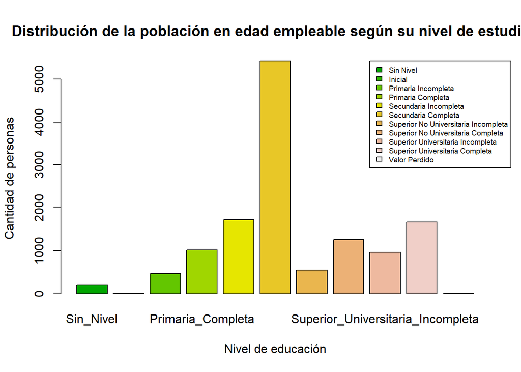

```r
grafico1=table(data2$p109a)
barplot(grafico1,
    col = terrain.colors(11),
    main="Distribución de la población en edad empleable según su nivel de estudios",
    xlab = "Nivel de educación",
    ylab = "Cantidad de personas",
    legend.text = c("Sin Nivel","Inicial","Primaria Incompleta","Primaria Completa","Secundaria Incompleta","Secundaria Completa","Superior No Universitaria Incompleta","Superior No Universitaria Completa","Superior Universitaria Incompleta","Superior Universitaria Completa","Valor Perdido"),
    args.legend = list(x = "topright", cex = 0.6, inset = c(-0.05,0)))
```

- edad (p108) La variable edad es la única variable numérica del conjunto de variables (independientes y dependiente) que se posee. Por ello, sí es posible calcular los estadísticos descriptivos y de dispersión de dicha variable

```r
summary(data2$p108)
```

```
##    Min. 1st Qu.  Median    Mean 3rd Qu.    Max.
##   14.00   26.00   41.00   42.08   56.00   98.00
```

```r
library("RcmdrMisc")
numSummary(data2$p108, statistics=c("mean", "sd", "IQR", "quantiles","cv", "skewness", "kurtosis"), type=c("2", "1", "3"),
           quantiles=c(0, .25, .5, .75, 1))
```

```
##      mean       sd IQR        cv  skewness   kurtosis 0% 25% 50% 75% 100%     n
##  42.08102 18.67406  30 0.4437645 0.3648675 -0.7508809 14  26  41  56   98 13268
```

Los estadísticos nos muestran que hay una media muestral de 42.08 años. El valor mínimo de la variable es 14 años, dado que desde dicha edad comienza la PET, y el valor máximo es de 98. La desviación estándar, por su parte, es de 18.67, un valor relativamente a comparación de la media, lo que muestra que los datos se encuentran dispersos. Respecto a la asimetría, esta posee un valor mayor que 0 (0.36), lo que evidencia una tendencia o agrupamiento de los datos hacia los valores inferiores del conjunto de datos. Asimismo, la curtosis es menor a 0 (-0.75), lo que evidencia que la distribución es platicúrtica y, por ende, es pequeña la concentración de los valores en torno al centro de la distribución.

- edad (p108) y empleo o no (p201) para finalizar el análisis descriptivo, se analizará la relación entre la variable edad y si el entrevistado o entrevistada poseía empleo o no la semana anterior.

```r
library(wesanderson)
```

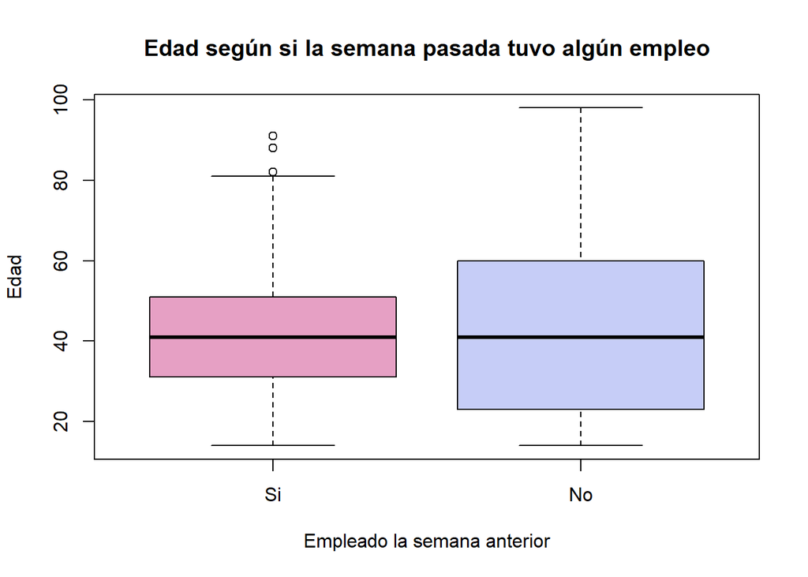

```r
boxplot(data2$p108~data2$p201, main = "Edad según si la semana pasada tuvo algún empleo",
     xlab = "Empleado la semana anterior", ylab = "Edad",
     col = wes_palette("GrandBudapest2"))
```

Como se puede apreciar en el gráfico, la mediana de edad, tanto para la población empleada como para la población no empleada, es de 40 o un valor muy cercano a esta cantidad. Además, la caja de la población no empleada es más gruesa que la de la población que sí lo está, lo que muestra un mayor rango intercuartil para los valores correspondientes a la población desempleada. Esto implica que existen más valores agrupados más allá de la mediana, a comparación de la población empleada. Del mismo modo, mientras en el gráfico de la población empleada se observa cierta equidistancia entre la caja y los límites, en la caja de la población desempleada se observa una tendencia hacia el límite inferior, lo que indica que hay un gran conjunto de datos agrupados en torno a los valores inferiores de la distribución. Un esbozo del análisis que se puede hacer a esto indicaría que es más difícil para las personas con menos edad conseguir trabajo. Finalmente, algo relevante que se puede extraer de este gráfico es también la diferencia entre los límites superiores de ambas cajas. Mientras que el límite superior de la caja de la población empleada es apróximadamente 80 años, el límite superior de la caja de la población no empleada es cercana a 100 (exactamente 98 si se consideran los estadísticos hallados anteriormente). Entonces, esta diferencia nos da indicios de que, por alguna razón, es improbable que la población mayor a 80 años se encuentre empleada en la región de Lima Metropolitana y Callao.

##Posibles pruebas estadísticas a utilizar para responder a pregunta de investigación: - modelo de regresión logística binaria, dado que variable dependiente es dicotómica (el entrevistado o entrevistada tuvo trabajo la semana anterior o no)

##Link del repositorio en GitHub: https://github.com/pierobenate/Trabajo-grupal-Estad-stica-2---Ch-vez-y-Benate-.git

Bibliografía: • Agencia EFE. (16 de noviembre de 2020). El desempleo en Perú creció el 9,6 % entre julio y septiembre por la covid-19. https://www.efe.com/efe/america/economia/el-desempleo-en-peru-crecio-9-6-entre-julio-y-septiembre-por-la-covid-19/20000011-4395700 • Huamán, Jackeline. (2021). Impacto económico y social de la COVID-19 en el Perú. Revista de Ciencia e Investigación en Defensa-CAEN. Vol 2, Núm 1. (pp. 31-42). • Jaramillo, Miguel. Ñopo, Hugo. (2020). Covid-19 y el shock externo: Impactos económicos y opciones de política en el Perú. Programa de las Naciones Unidas para el Desarrollo. COVID-19 Serie de Documentos de Política Pública: Propuestas de soluciones para la crisis. N° 5. • Instituto Nacional de Estadística e Informática. (2020). Encuesta permanente de empleo de la INEI, correspondiente mayo - junio- julio 2020. Dirección Técnica de Demografía e Indicadores Sociales. • Instituto Nacional de Estadística e Informática. (2021). Situación del Mercado Laboral en Lima Metropolitana (N° 8 - Agosto 2021) • Instituto Peruano de Economía. (2021, 4 de enero). En busca del empleo perdido. El Comercio. • Instituto Peruano de Economía. (2020). MERCADO LABORAL PERUANO: IMPACTO POR COVID-19 Y RECOMENDACIONES DE POLÍTICA. Instituto Peruano de Economía en colaboración con la Organización Internacional del Trabajo y la Confederación Nacional de Instituciones Empresariales Privadas.